# QUK2 SH WJ Leak Test Data Exploratory Analysis

Jim Yan

30 March 2018

## QUK2 SH WJ Air Decay Leak Test - Water Passsage Section

### Dataset at glance

Data was extrated from raw data by running script “0-ExtractCleanData-LeakTestStation.R”.

Remarks of the extraction process:

- Duplicates was not removed.
- All processed data include duplicates and was sorted in order of time/part_id.
- Data from the same file will be subset into 3 different data set with similar structure.
- Within the same table, the Rows contained NA was removed.

Datasets were saved into below files:

- DataOutput/dt.AirDecay.WP.Full.RDS
- DataOutput/dt.AirDecay.MC.Full.RDS
- DataOutput/dt.AirDecay.He.Full.RDS

### Observation Leak Rate from Jan2018 to Mar2018

Now summarizing the daily statics of the leak rate from JAN/2018 to Mar/2018.

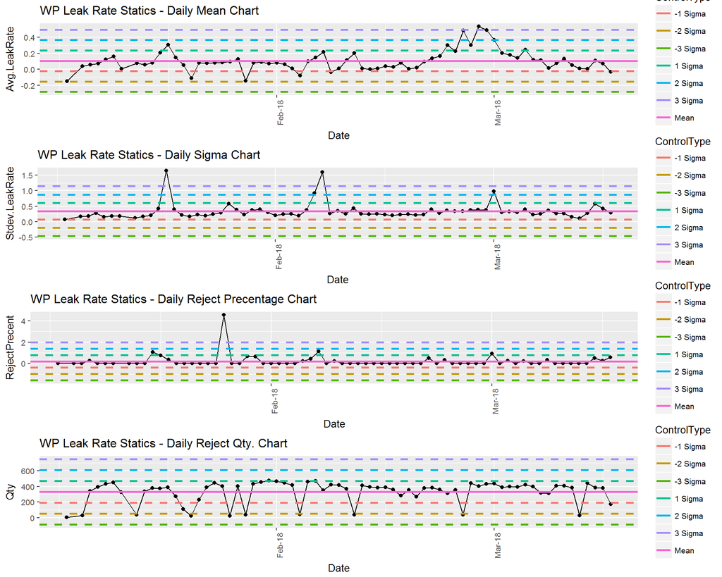

### Establish Contorl Limit of Leak Rate

Establishing contorl limits from goods dates in 2018: 10/JAN/2018 to 16/JAN/2018, 1~4/FEB, 20/FEB, 22/FEB.

Contorl Limits of leak rate was set as below:

- Mean Contorl Limit = 0.0836815
- Sigma Contorl Limit = 0.2204271

### Observation Leak Rate from Jan2017 to Mar2018

Now summarizing the daily statics of the leak rate from JAN/2017 to Mar/2018.

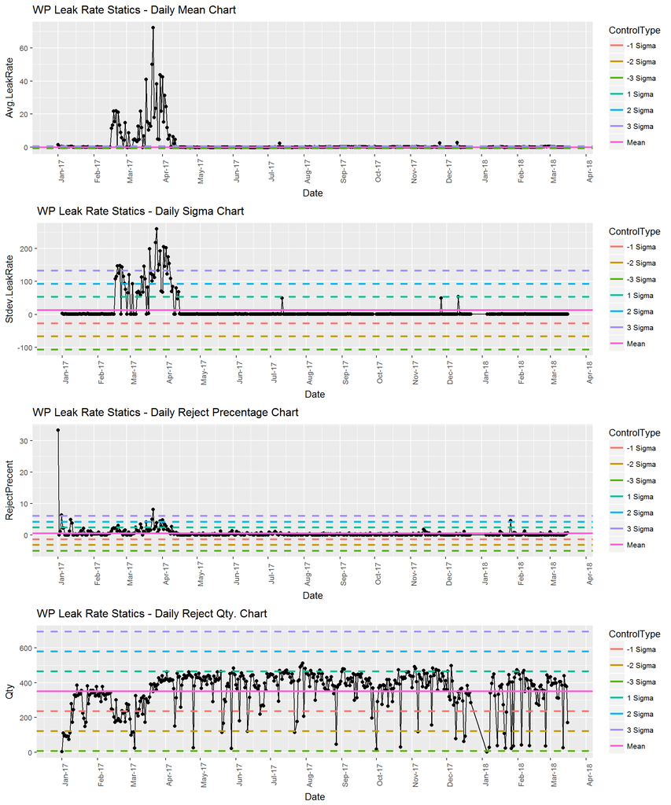

### Observation - leak rate in Jan-17

- 03~06 JAN 2017;
- 11~13 JAN 2017;

The basics statics of this dataset is present as below:

| CastMC_Die | Qty | RejectPrecent | Avg.LeakRate | Stdev.LeakRate |
| --- | --- | --- | --- | --- |
| CastMC#01Die#01 | 419 | 1.6706444 | 0.1250597 | 0.5823703 |
| CastMC#02Die#01 | 552 | 1.8115942 | 0.2130435 | 0.9463907 |
| CastMC#02Die#02 | 5968 | 0.8545576 | 0.1278150 | 0.9279583 |

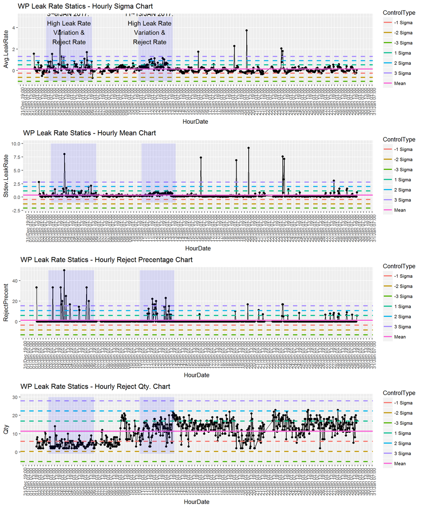

### Observation - leak rate in 03~06/Jan/17